# Math 421 - Midterm

## III. Predictive Models

Continue with the data from part I. Make sure you do not have any missing values in the data. Use the follows as the target and input variables:

*Target Variable*: Create the target variable taking value of

- `low` if the total charge of a patient (`tot`) is smaller than the median of the total charge, and

```r
df <- read.csv('midterm.csv')
df <- df %>% select("age","sex","raceethn","provider","moa","mod","admtype","campus", "los","tot")
df$target = ifelse(df$tot<median(df$tot),'low','high')
```

- `high` otherwise.

*Input Variables*:

- “age”,“sex”,“raceethn”,“provider”,“moa”,“mod”,“admtype”,“campus”, ‘los’

```r
df <- df %>%
  mutate(sex = as.factor(sex),
         moa = as.factor(moa),
         mod = as.factor(mod),
         target = as.factor(target))
```

1. Use `filter` function to filter out rows where `raceethn==''` or `admtype==''`. Make sure all the categorical variables are factor, numeric variables are numeric. Set Training : Testing Split = 10 : 90

```r
df <- df %>%
  filter(!is.na(raceethn)&!is.na(admtype))
df <- df %>% select(-tot)
set.seed(2020)
splitIndex <- createDataPartition(df$target, p = .10,
                                  list = FALSE)
df_train <- df[ splitIndex,]
df_test <- df[-splitIndex,]
```

2. Train a decision tree using `rpart`. Plot the decision tree. Plot the variable importance ranked by the tree.

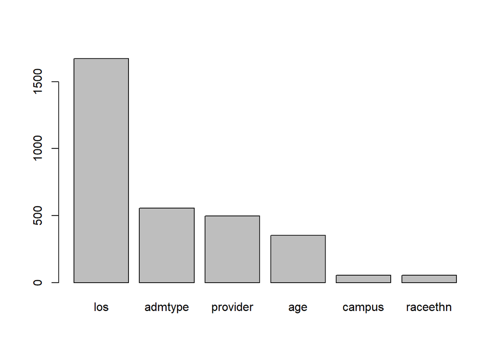

```r
model <- rpart(target ~ ., data = df_train,
                    control = rpart.control(maxdepth = 3))
barplot(model$variable.importance)
```

[figure not shown]

```r
fancyRpartPlot(model)
```

3. Using caret for this question. Set `Training Control` to be: Use Cross-Validation of 5 folds across all models. Train & tune at least 2 different models (i.e. two different values for `method=` in the train function of caret). Plot the hyper-parameter tuning plots for each model.

```r
trControl = trainControl(method = "cv",
                         number = 5)
model2 <- train(target~.,
               method = "rpart2",
               data = df_train,
               trControl = trControl)
```

```r
model3 <- train(target~.,
               method = "ranger",
               data = df_train,
               trControl = trControl)
```

4. Plot the comparison of the models in 3.

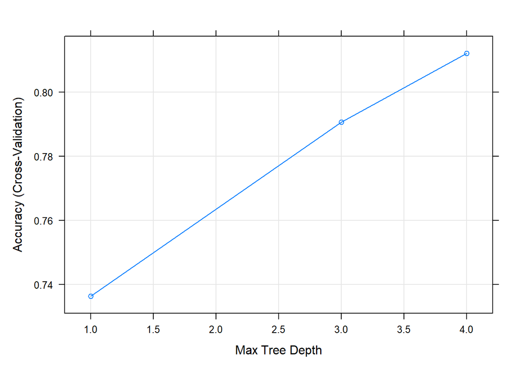

```r
plot(model2)
```

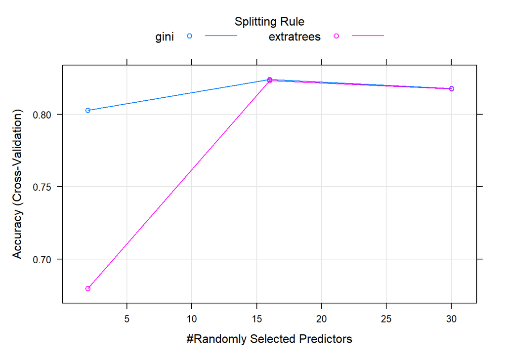

```r
plot(model3)
```

5. What is your final selection for the model? Test the accuracy of your final model on the test data.

```r
pred <- predict(model2, df_test)
cm2 <- confusionMatrix(data = pred, reference = df_test$target)
cm2$overall[1]
```

```
##  Accuracy
## 0.8136425
```

```r
pred <- predict(model3, df_test)
cm3 <- confusionMatrix(data = pred, reference = df_test$target)
cm3$overall[1]
```

```
##  Accuracy
## 0.8213968
```

```r
#model3, the ranger model, or the second model from part 3, is better according to accuracy
```

6. Create another `target` variable (binary), decide the input variables and redo 1 to 5.

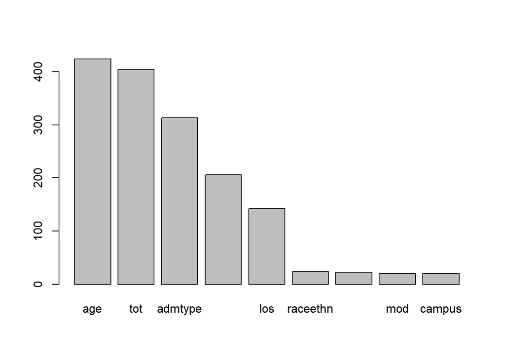

```r
df <- read_csv('midterm.csv')
df <- df %>% select("age","sex","raceethn","provider","moa","mod","admtype","campus", "los","tot")
df <- df %>% filter(sex<3)
df <- df %>% rename(target = sex)
df <- df %>%
  mutate(target = as.factor(target))
df <- df %>%
  filter(!is.na(raceethn)&!is.na(admtype))
set.seed(2020)
splitIndex <- createDataPartition(df$target, p = .10,
                                  list = FALSE)
df_train <- df[ splitIndex,]
df_test <- df[-splitIndex,]
model <- rpart(target ~ ., data = df_train,
               control = rpart.control(minsplit = 1,
                                      minbucket = 1,
                                      cp = 0.001))
barplot(model$variable.importance)
```

[figure not shown]

```r
fancyRpartPlot(model)
```

```r
#I know that this is horrendous but it was the only band-aid job that I could get to work to actually print this model... the next few models I use will be much better
```

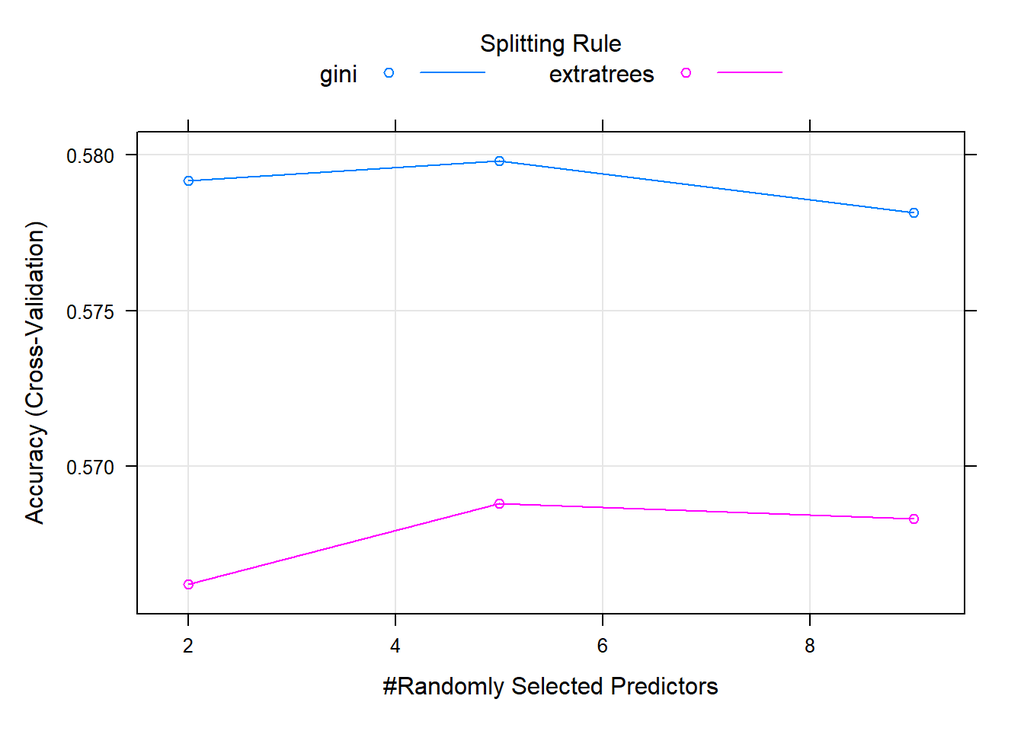

```r
trControl = trainControl(method = "cv",
                         number = 5)
model <- train(target~.,
               data = df_train,
               method = "ranger",
               trControl = trControl)

model2 <- train(target~.,
               method = "rpart2",
               data = df_train,
               trControl = trControl)
plot(model)
```

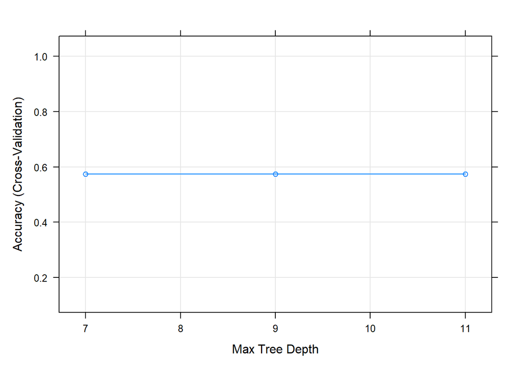

```r
plot(model2)
```

```r
pred <- predict(model, df_test)
cm <- confusionMatrix(data = pred, reference = df_test$target)
cm$overall[1]
```

```
##  Accuracy
## 0.5889954
```

```r
pred <- predict(model2, df_test)
cm1 <- confusionMatrix(data = pred, reference = df_test$target)
cm1$overall[1]
```

```
##  Accuracy
## 0.5519735
```

```r
#model 1, the ranger model, is better according to accuracy
```

7. Write a paragraph to summarize the section and give your comments on the results.

```r
#I thought this section was really interesting as this would be the practical
#use for R if I were to start working as a data analyst right now. I enjoyed
#this section because of the amount of problem solving I had to do as well as
#the fact that these types of problems seemed pretty intuitive to me so taking
#a moment to examine what I have written always helped the problem I was having.
```